Skip to contents

# Inference on the biplot

Muhammad Yaseen

2026-11-05

Source: [`vignettes/bayesammi_04_biplots.qmd`](https://github.com/myaseen208/bayesammi/blob/HEAD/vignettes/bayesammi_04_biplots.qmd)

## 1 Abstract

A least-squares AMMI biplot shows point estimates only. Its Bayesian counterpart gives every genotype and environment a highest posterior density (HPD) region. A region that contains the origin marks a stable genotype or environment, regions that overlap mark a homogeneous group, and the marginal interval on the first term decides the direction of the interaction. This vignette shows how `biplots()` builds the regions and how to read them.

## 2 The coordinates

For draw $s$ the point of genotype $i$ is $\left(\lambda_1^{(s)1/2}\alpha^{(s)}_{i1}, \lambda_2^{(s)1/2}\alpha^{(s)}_{i2}\right)$. The draws of a genotype form a cloud whose shape shows the uncertainty of its interaction.

```r
fit <-
  bayes_ammi(
      .data   = Maiz
    , .y      = y
    , .gen    = entry
    , .env    = site
    , .rep    = rep
    , .nIter  = 6000
    , .k      = 2
    , .burnin = 1000
    , .thin   = 1
    , .chains = 2
    , .priors = bam_priors(
          mu_mean     = 0
        , mu_var      = 1e+8
        , tau_mean    = 0
        , tau_var     = 1e+8
        , delta_mean  = 0
        , delta_var   = 1e+8
        , lambda_mean = 0
        , lambda_var  = 1e+8
        , nu          = 1
        , s2          = NULL
        )
    , .level  = 0.95
    , .seed   = 4
    , .align  = TRUE
    , .model  = "AMMI"
    , .het    = FALSE
    , .waic   = TRUE
    )
```

## 3 HPD regions

A bivariate kernel density $\hat{f}$ is estimated from the cloud. The $100(1-p)\%$ HPD region is the set where $\hat{f}$ exceeds the $p$-quantile of $\hat{f}$ at the draws, so it holds $100(1-p)\%$ of them and is the smallest such set (Hyndman 1996). It contains the origin exactly when $\hat{f}(\mathbf{0})$ reaches that quantile.

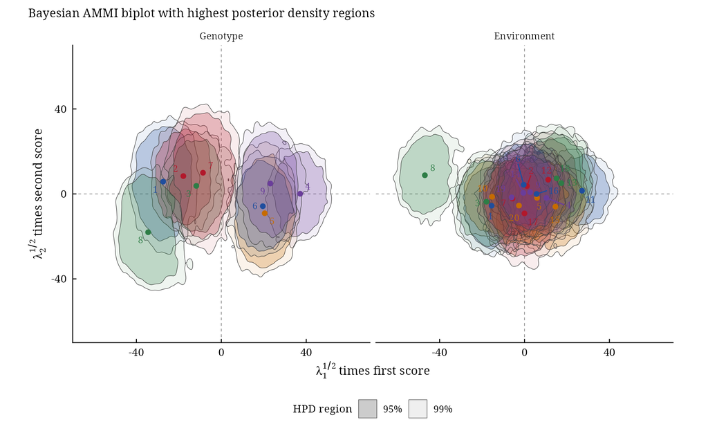

```r
bp <-
  biplots(
      model         = fit
    , burnin        = 0
    , thin          = 0.5
    , pb            = c(0.05, 0.01)
    , plot_stable   = TRUE
    , plot_unstable = TRUE
    , ncolors       = 5
    , .which        = "both"
    , .grid         = 100
    )
bp$biplot
```

## 4 Stable genotypes and environments

```r
bp$biplot_data[, list(byplot, name, x, y, stable, axis1_lower, axis1_upper, group)]
```

```
         byplot   name            x            y stable  axis1_lower
         <char> <char>        <num>        <num> <lgcl>        <num>
 1:    Genotype      1 -27.39165676   5.76438212  FALSE -38.27946935
 2:    Genotype      2 -17.88925076   8.40300672  FALSE -28.32124518
 3:    Genotype      3 -11.78567779   3.78193269   TRUE -22.73533406
 4:    Genotype      4  37.11735449   0.09401861  FALSE  26.60001160
 5:    Genotype      5  20.43844153  -9.10673615  FALSE   9.03528012
 6:    Genotype      6  19.54334049  -5.78161457  FALSE   8.91289231
 7:    Genotype      7  -8.63141072   9.96597984   TRUE -19.98012491
 8:    Genotype      8 -34.47493736 -18.02866280  FALSE -45.52039819
 9:    Genotype      9  23.07379688   4.90769355  FALSE  12.32697873
10: Environment      1 -15.50657921  -5.55082820  FALSE -26.34872405
11: Environment      2   1.17617282   3.68818862   TRUE  -9.69787599
12: Environment      3 -17.92256587  -3.66236650  FALSE -28.83775413
13: Environment      4  10.29797179  -1.87419076   TRUE  -0.05076488
```

[output cut: 51 more lines]

- `stable = TRUE`: the 95% region contains the origin, so the interaction of the genotype (environment) is not different from zero on the two terms jointly.
- `group`: the marginal 95% HPD interval of the first coordinate. “positive” and “negative” groups interact in opposite directions; the paper uses this criterion.

A genotype can be stable in the joint sense and still have a first coordinate that differs from zero. This happens when the second term is so uncertain that the region stretches over the origin along the second axis.

## 5 Only the unstable ones

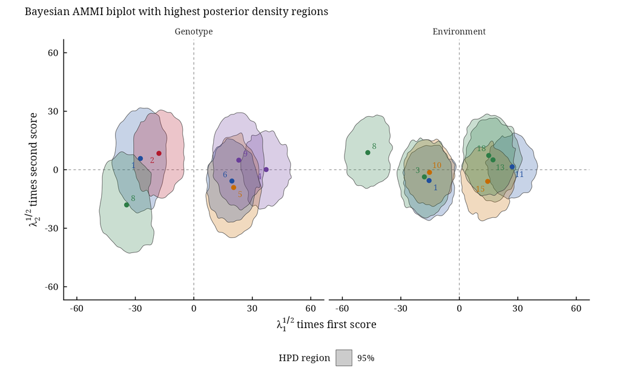

```r
bp_u <-
  biplots(
      model         = fit
    , burnin        = 0
    , thin          = 0.5
    , pb            = 0.05
    , plot_stable   = FALSE
    , plot_unstable = TRUE
    , ncolors       = 5
    , .which        = "both"
    , .grid         = 100
    )
bp_u$biplot
```

## 6 Reading genotype and environment together

A genotype yields more than its main effects predict in environments whose first scores have the same sign as its own, and less where the signs differ. The genotypes in the positive group are therefore adapted to the environments in the positive group.

```r
bam_interpret(
    x             = bp
  , higher_better = TRUE
  , top           = 5
  )
```

```
Biplot with highest posterior density regions

7 of 9 genotypes and 8 of 20 environments have a 95% HPD region that excludes
the origin (significant interaction).

Findings:
- Genotypes whose region contains the origin (interaction not different from
  zero, stable): 3 and 7.
- Groups on the first term (marginal HPD interval excludes zero): positive 4,
  5, 6 and 9; negative 1, 2, 3 and 8.
- Environments on the first term: positive 11, 13, 15 and 18; negative 1, 3,
  8 and 10; the others do not differ from zero.
- Overlapping regions mark genotypes (environments) whose interaction
  parameters do not differ: a homogeneous group.

Recommendations:
- Genotypes 4, 5, 6 and 9 are adapted to environments 11, 13, 15 and 18 (both
  positive on the first term).
- Genotypes 1, 2, 3 and 8 are adapted to environments 1, 3, 8 and 10 (both
  negative on the first term).

Cautions:
- The regions are estimated from the draws by a kernel density; with few
  draws their outline is rough.
- The second term is usually estimated with much more uncertainty than the
  first: long regions along the second axis.

Sources:
- Crossa, J., Perez-Elizalde, S., Jarquin, D., Cotes, J. M., Viele, K., Liu,
  G. and Cornelius, P. L. (2011). Bayesian estimation of the additive main
  effects and multiplicative interaction model. Crop Science, 51(4),
  1458-1469. doi:10.2135/cropsci2010.06.0343
```

## 7 References

Crossa, J., Perez-Elizalde, S., Jarquin, D., Cotes, J. M., Viele, K., Liu, G. and Cornelius, P. L. (2011). Bayesian estimation of the additive main effects and multiplicative interaction model. *Crop Science*, 51(4), 1458–1469. doi:10.2135/cropsci2010.06.0343

Hyndman, R. J. (1996). Computing and graphing highest density regions. *The American Statistician*, 50(2), 120–126.